# Transported Hessian Transport-Confidence Filter Validation

# Purpose

The transported graph Hessian compares directional derivatives across a graph edge. For a base dart $u\to u'$, a direction $u\to v$, and a matched direction $u'\to v'$, the row is

$$\delta_{u'\to v'} f - \delta_{u\to v} f,
\qquad
\delta_{a\to b} f = \frac{f(b)-f(a)}{\ell_{ab}}.$$

The previous backend validation showed that true edge-KK local coordinate repair can be used and audited. It also showed that better edge stress alone does not guarantee a better transported Hessian. The next question is whether we should reject low-confidence direction transports before they become rows of the operator.

This report evaluates five transport policies:

$$\text{no filter},\quad
\theta_1\le \pi/3\ \text{and}\ r_\ell\le 0.50,\quad
\text{local quantile},\quad
\text{local robust-}z,\quad
\text{local robust-}z+\text{entropy fraction},$$

where $s_1$ and $s_2$ are the best and second-best match scores, $H$ is softmax entropy, $\theta_1$ is the best-match angle, and

$$r_\ell =
\frac{|\ell_{\mathrm{matched}}-\ell_{\mathrm{direction}}|}
{\ell_{\mathrm{direction}}}.$$

The local rules compare each candidate direction match against the alternatives available at the same transported vertex. For sorted candidate scores $s$, score gaps $\Delta s$, and robust scale $\operatorname{scale}(x)=1.4826\,\operatorname{MAD}(x)$ with fallbacks, the adaptive diagnostics are

$$q_s = \widehat F_s(s_1), \qquad
q_m = \widehat F_{\Delta s}(s_2-s_1),$$

and

$$z_s = \frac{\operatorname{median}(s)-s_1}{\operatorname{scale}(s)},
\qquad
z_m = \frac{(s_2-s_1)-\operatorname{median}(\Delta s)}
{\operatorname{scale}(\Delta s)}.$$

The entropy-fraction gate uses

$$\rho_H = \frac{\exp(H)}{n_{\mathrm{candidate}}},$$

so that the same effective-match count is judged relative to local degree.

**Build:** 2026-05-18 19:06:54 EDT  
**Mode:** smoke  
**Local grip requested:** TRUE  
**True edge-KK available:** TRUE  
**Edge-KK function:** `grip.optimize.edge.kk.layout`

# Row Retention

Filtering can only help if it removes questionable rows without destroying the operator. The retention fraction is

$$\rho =
\frac{\#\{\text{accepted Hessian rows}\}}
{\#\{\text{candidate direction transports}\}}.$$

High retention means the filter is conservative. Very low retention is a warning: polynomial residuals may look artificially good if the operator has become too small to test anything.

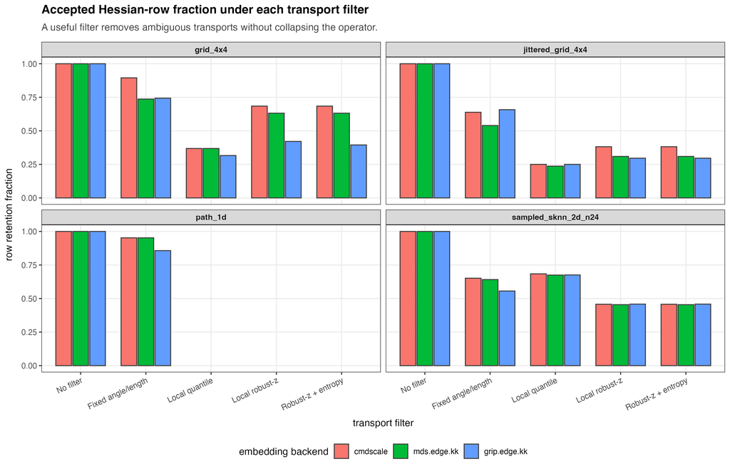

The retention plot is the first safety check. A filter that drops nearly all rows may reduce residuals for the wrong reason. A filter that drops nothing cannot teach us much about transport confidence.

# Why Rows Were Dropped

The confidence gates are intentionally interpretable. A candidate can be dropped because the best angle is too large, the best length mismatch is too large, the local score quantile is not selective enough, the local robust z-score is too weak, or the softmax distribution is too diffuse relative to the local candidate count.

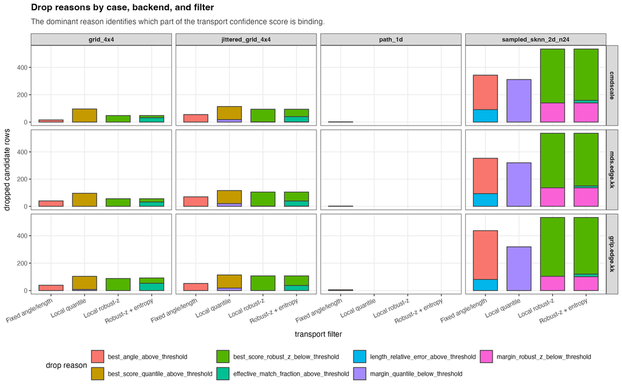

This figure explains the mechanism behind row loss. If all drops come from local robust-z or quantile thresholds, the local geometry produces tied or nearly tied directions. If drops come from angle or length, the candidate has a clear best match but the match is geometrically implausible. If drops come from effective-match fraction, the soft transport remains too spread out after local calibration.

# Confidence Diagnostics

The row filters should improve the confidence diagnostics of the rows that remain. We summarize the accepted rows by the adaptive quantities used by the new gates: best-score robust $z$, margin robust $z$, effective-match fraction, and margin quantile.

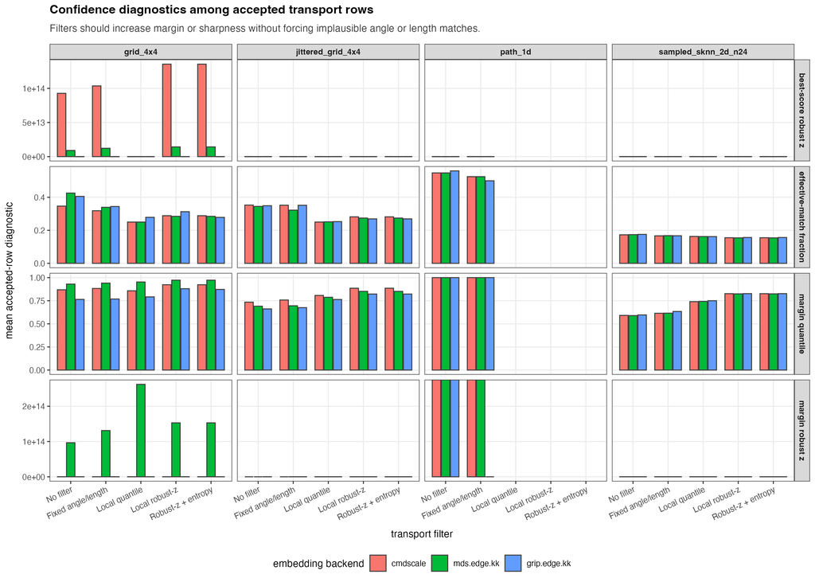

These diagnostics are descriptive rather than final objectives. For example, a low effective-match fraction is good only if the selected direction is a geometrically meaningful match and the retained rows still test the polynomial probes.

# Polynomial Residuals

The core mathematical check is how the filtered operator acts on simple polynomial probes. For a probe matrix $P$, we report

$$R(P) = \frac{\|AP\|_F}{\|P\|_F}.$$

For a transported second-difference operator, constants and linear coordinate probes are the most important sanity checks. Lower residuals are better only when row retention remains high enough for the operator to be meaningful.

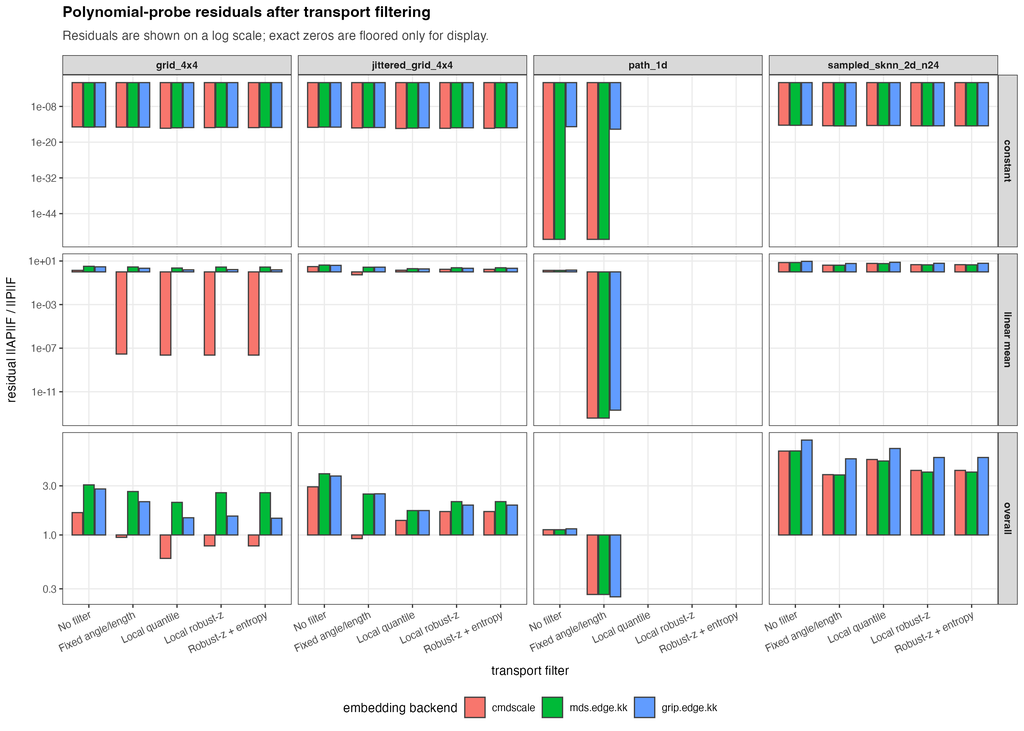

This plot is the main evidence about whether confidence filtering helps the operator mathematically. The desired pattern is lower constant/linear residuals with only moderate row loss.

# Nullity And Operator Size

Nullity is a coarse global check. If a filter drops many rows, the nullity can increase simply because the operator has fewer constraints. We therefore read nullity together with row retention and residuals.

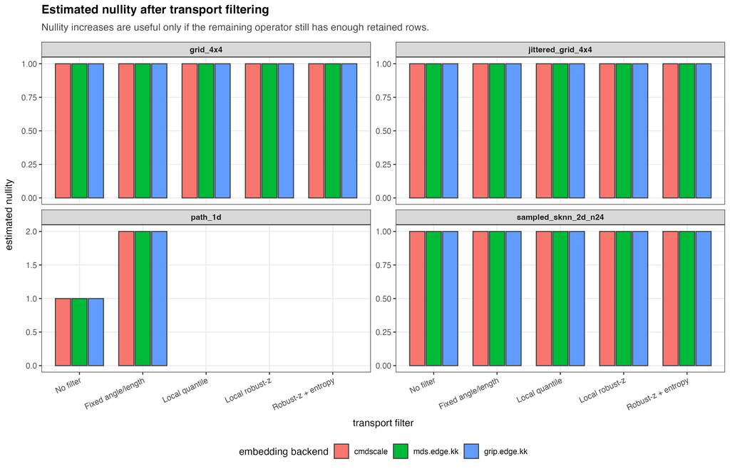

The nullity plot distinguishes true improvement from degeneracy. A filter that raises nullity while retaining few rows is not a solved transport rule; it is a diagnostic that we are rejecting too many constraints.

# Results Summary And Discussion

Best linear-residual-with-retention compromise by case.

|  | case.id | local.embedding.method | transport.filter | row.retention | residual.linear.mean | nullity.estimate | mean.best.score.robust.z | mean.margin.robust.z | mean.effective.match.fraction |
| --- | --- | --- | --- | --- | --- | --- | --- | --- | --- |
| 17 | grid_4x4 | cmdscale | Fixed angle/length | 0.8947 | 0.0000 | 1 | 1.035945e+14 | 0.5708 | 0.3186 |
| 32 | jittered_grid_4x4 | cmdscale | Fixed angle/length | 0.6382 | 0.5390 | 1 | 1.871700e+00 | 0.0786 | 0.3521 |
| 2 | path_1d | cmdscale | Fixed angle/length | 0.9524 | 0.0000 | 2 | 6.408000e-01 | Inf | 0.5250 |
| 47 | sampled_sknn_2d_n24 | cmdscale | Fixed angle/length | 0.6514 | 4.1374 | 1 | 1.640000e+00 | 0.6312 | 0.1666 |

The experiment asks whether local confidence filtering improves the transported Hessian in a way that survives basic mathematical checks. The adaptive policies are designed to avoid one global threshold pretending that a path endpoint, a grid interior vertex, and a sampled kNN neighborhood have the same candidate geometry. Confidence filtering now removes low-quality rows for auditable reasons: weak local score separation, weak local margin separation, diffuse softmax mass, and geometrically implausible angle/length matches.

The residual plots show that filtering can change the polynomial behavior, but row retention is the controlling caveat. A filter that makes residuals smaller by dropping too many rows is not a valid default. The most promising filters are therefore the ones that reduce linear residuals while keeping row retention close to the unfiltered operator.

# What We Learned

1. Transport confidence must be treated as a first-class diagnostic. Backend quality alone is not enough.
2. The most interpretable quantities are best-match margin, effective match count, best-match angle, and relative length error.
3. Filtering should be judged jointly by row retention and polynomial residuals. Residuals alone can be misleading when the operator is heavily thinned.
4. Adaptive thresholds are now implemented as first-class policy choices. The next refinement should calibrate their defaults against separate graph families rather than tuning them on a single report.

# Appendix

## Run Metadata

```
## List of 7
##  $ mode             : chr "smoke"
##  $ generated.at     : chr "2026-05-18 19:06:54 EDT"
##  $ use.local.grip   : logi TRUE
##  $ grip.available   : logi TRUE
##  $ edge.kk.available: logi TRUE
##  $ edge.kk.function : chr "grip.optimize.edge.kk.layout"
##  $ gflow.repo       : chr "/Users/pgajer/current_projects/gflow"
```

## Filter Policies

| transport.filter | filter.label | description | max.match.angle | max.length.relative.error | min.match.margin | max.effective.matches | match.threshold.rule | match.score.quantile | match.margin.quantile | min.best.score.z | min.margin.z | max.effective.match.fraction |
| --- | --- | --- | --- | --- | --- | --- | --- | --- | --- | --- | --- | --- |
| none | No filter | All candidate soft-transport rows are retained. | NA | NA | NA | NA | fixed | NA | NA | NA | NA | NA |
| fixed_geometric | Fixed angle/length | Retain rows only when the best match has angle at most pi/3 and relative length error at most 0.50. | 1.0472 | 0.5 | NA | NA | fixed | NA | NA | NA | NA | NA |
| local_quantile | Local quantile | Retain rows only when the best score is in the local lower quartile and the best-vs-second margin is at least the local median margin. | NA | NA | NA | NA | local.quantile | 0.25 | 0.5 | NA | NA | NA |
| local_robust_z | Local robust-z | Retain rows only when the best match is at least one robust scale better than the local median score and its margin is not below the local median gap. | NA | NA | NA | NA | local.robust.z | NA | NA | 1 | 0 | NA |
| local_robust_z_entropy | Robust-z + entropy | Apply the local robust-z rule and additionally reject diffuse softmax matches by effective-match fraction. | NA | NA | NA | NA | local.robust.z | NA | NA | 1 | 0 | 0.35 |

## Summary Table

| case.id | graph.type | n.vertices | expected.dimension | local.embedding.method | transport.filter | status | runtime.sec | nullity.estimate | n.candidate.rows | n.rows | n.row.records | n.dropped | row.retention | median.edge.stress | median.graph.distance.stress | mean.transport.entropy | mean.effective.matches | mean.effective.match.fraction | mean.match.score | mean.best.score.robust.z | mean.margin.robust.z | mean.best.score.local.quantile | mean.margin.local.quantile | mean.best.match.margin | mean.best.match.angle | mean.best.length.relative.error | backend.used | fallback.reason | message | … |
| --- | --- | --- | --- | --- | --- | --- | --- | --- | --- | --- | --- | --- | --- | --- | --- | --- | --- | --- | --- | --- | --- | --- | --- | --- | --- | --- | --- | --- | --- | --- |
| path_1d | path | 12 | 1 | cmdscale | none | ok | 0.440 | 1 | 42 | 42 | 80 | 0 | 1.00000 | 0.00000 | 0.00000 | 0.00000 | 1.00000 | 0.54762 | 0.97500 | 6.102500e-01 | Inf | 0.54762 | 1.00000 | Inf | 0.14963 | 0.00000 | cmdscale | NA | NA | … |
| path_1d | path | 12 | 1 | cmdscale | fixed_geometric | ok | 0.193 | 2 | 42 | 40 | 78 | 2 | 0.95238 | 0.00000 | 0.00000 | 0.00000 | 1.00000 | 0.52500 | 0.97436 | 6.407700e-01 | Inf | 0.52500 | 1.00000 | Inf | 0.00003 | 0.00000 | cmdscale | NA | NA | … |
| path_1d | path | 12 | 1 | cmdscale | local_quantile | error | 0.043 | NA | NA | NA | NA | NA | NA | NA | NA | NA | NA | NA | NA | NA | NA | NA | NA | NA | NA | NA | NA | NA | Error in svd(x, 0, 0) : a dimension is zero | … |
| path_1d | path | 12 | 1 | cmdscale | local_robust_z | error | 0.045 | NA | NA | NA | NA | NA | NA | NA | NA | NA | NA | NA | NA | NA | NA | NA | NA | NA | NA | NA | NA | NA | Error in svd(x, 0, 0) : a dimension is zero | … |
| path_1d | path | 12 | 1 | cmdscale | local_robust_z_entropy | error | 0.044 | NA | NA | NA | NA | NA | NA | NA | NA | NA | NA | NA | NA | NA | NA | NA | NA | NA | NA | NA | NA | NA | Error in svd(x, 0, 0) : a dimension is zero | … |
| path_1d | path | 12 | 1 | mds.edge.kk | none | ok | 0.221 | 1 | 42 | 42 | 80 | 0 | 1.00000 | 0.00000 | 0.00000 | 0.00000 | 1.00000 | 0.54762 | 0.97500 | 6.102500e-01 | Inf | 0.54762 | 1.00000 | Inf | 0.14963 | 0.00000 | cmdscale+grip.optimize.edge.kk.layout | NA | NA | … |
| path_1d | path | 12 | 1 | mds.edge.kk | fixed_geometric | ok | 0.107 | 2 | 42 | 40 | 78 | 2 | 0.95238 | 0.00000 | 0.00000 | 0.00000 | 1.00000 | 0.52500 | 0.97436 | 6.407700e-01 | Inf | 0.52500 | 1.00000 | Inf | 0.00003 | 0.00000 | cmdscale+grip.optimize.edge.kk.layout | NA | NA | … |
| path_1d | path | 12 | 1 | mds.edge.kk | local_quantile | error | 0.158 | NA | NA | NA | NA | NA | NA | NA | NA | NA | NA | NA | NA | NA | NA | NA | NA | NA | NA | NA | NA | NA | Error in svd(x, 0, 0) : a dimension is zero | … |
| path_1d | path | 12 | 1 | mds.edge.kk | local_robust_z | error | 0.069 | NA | NA | NA | NA | NA | NA | NA | NA | NA | NA | NA | NA | NA | NA | NA | NA | NA | NA | NA | NA | NA | Error in svd(x, 0, 0) : a dimension is zero | … |
| path_1d | path | 12 | 1 | mds.edge.kk | local_robust_z_entropy | error | 0.061 | NA | NA | NA | NA | NA | NA | NA | NA | NA | NA | NA | NA | NA | NA | NA | NA | NA | NA | NA | NA | NA | Error in svd(x, 0, 0) : a dimension is zero | … |
| path_1d | path | 12 | 1 | grip.edge.kk | none | ok | 0.175 | 1 | 42 | 42 | 80 | 0 | 1.00000 | 0.78873 | 0.68464 | 0.01741 | 1.02473 | 0.55999 | 0.65000 | 6.102500e-01 | Inf | 0.54762 | 1.00000 | Inf | 0.43701 | 0.00000 | grip.layout.weighted+grip.optimize.edge.kk.layout | NA | NA | … |
| path_1d | path | 12 | 1 | grip.edge.kk | fixed_geometric | ok | 0.108 | 2 | 42 | 36 | 72 | 6 | 0.85714 | 0.78873 | 0.68464 | 0.00000 | 1.00000 | 0.50000 | 0.61111 | 6.744900e-01 | 0.000000e+00 | 0.50000 | 1.00000 | 1.22222 | 0.00000 | 0.00000 | grip.layout.weighted+grip.optimize.edge.kk.layout | NA | NA | … |
| path_1d | path | 12 | 1 | grip.edge.kk | local_quantile | error | 0.072 | NA | NA | NA | NA | NA | NA | NA | NA | NA | NA | NA | NA | NA | NA | NA | NA | NA | NA | NA | NA | NA | Error in svd(x, 0, 0) : a dimension is zero | … |
| path_1d | path | 12 | 1 | grip.edge.kk | local_robust_z | error | 0.070 | NA | NA | NA | NA | NA | NA | NA | NA | NA | NA | NA | NA | NA | NA | NA | NA | NA | NA | NA | NA | NA | Error in svd(x, 0, 0) : a dimension is zero | … |
| path_1d | path | 12 | 1 | grip.edge.kk | local_robust_z_entropy | error | 0.067 | NA | NA | NA | NA | NA | NA | NA | NA | NA | NA | NA | NA | NA | NA | NA | NA | NA | NA | NA | NA | NA | Error in svd(x, 0, 0) : a dimension is zero | … |
| grid_4x4 | grid | 16 | 2 | cmdscale | none | ok | 0.455 | 1 | 152 | 152 | 488 | 0 | 1.00000 | 1.17340 | 0.77006 | 0.03648 | 1.05263 | 0.34649 | 0.98385 | 9.268978e+13 | 4.752500e-01 | 0.33114 | 0.86842 | 0.82289 | 0.37559 | 0.00000 | cmdscale | NA | NA | … |
| grid_4x4 | grid | 16 | 2 | cmdscale | fixed_geometric | ok | 0.428 | 1 | 152 | 136 | 448 | 16 | 0.89474 | 1.17340 | 0.77006 | 0.00000 | 1.00000 | 0.31863 | 0.95392 | 1.035945e+14 | 5.708300e-01 | 0.31863 | 0.88235 | 0.88477 | 0.24840 | 0.00000 | cmdscale | NA | NA | … |
| grid_4x4 | grid | 16 | 2 | cmdscale | local_quantile | ok | 0.291 | 1 | 152 | 56 | 224 | 96 | 0.36842 | 1.17340 | 0.77006 | 0.00000 | 1.00000 | 0.25000 | 0.98153 | 1.426560e+00 | 1.000880e+00 | 0.25000 | 0.85714 | 0.85529 | 0.09711 | 0.00000 | cmdscale | NA | NA | … |
| grid_4x4 | grid | 16 | 2 | cmdscale | local_robust_z | ok | 0.399 | 1 | 152 | 104 | 368 | 48 | 0.68421 | 1.17340 | 0.77006 | 0.00000 | 1.00000 | 0.28846 | 0.91277 | 1.354697e+14 | 8.502400e-01 | 0.28846 | 0.92308 | 0.87516 | 0.13745 | 0.00000 | cmdscale | NA | NA | … |
| grid_4x4 | grid | 16 | 2 | cmdscale | local_robust_z_entropy | ok | 0.391 | 1 | 152 | 104 | 368 | 48 | 0.68421 | 1.17340 | 0.77006 | 0.00000 | 1.00000 | 0.28846 | 0.91277 | 1.354697e+14 | 8.502400e-01 | 0.28846 | 0.92308 | 0.87516 | 0.13745 | 0.00000 | cmdscale | NA | NA | … |
| grid_4x4 | grid | 16 | 2 | mds.edge.kk | none | ok | 0.526 | 1 | 152 | 152 | 488 | 0 | 1.00000 | 0.03488 | 0.59804 | 0.14600 | 1.21060 | 0.42546 | 0.96884 | 8.982669e+12 | 9.659594e+13 | 0.33114 | 0.92982 | 0.56013 | 0.94338 | 0.00000 | cmdscale+grip.optimize.edge.kk.layout | NA | NA | … |
| grid_4x4 | grid | 16 | 2 | mds.edge.kk | fixed_geometric | ok | 0.453 | 1 | 152 | 112 | 384 | 40 | 0.73684 | 0.03488 | 0.59804 | 0.04951 | 1.07143 | 0.33929 | 0.95773 | 1.219077e+13 | 1.310945e+14 | 0.30357 | 0.94048 | 0.73552 | 0.36599 | 0.00000 | cmdscale+grip.optimize.edge.kk.layout | NA | NA | … |
| grid_4x4 | grid | 16 | 2 | mds.edge.kk | local_quantile | ok | 0.370 | 1 | 152 | 56 | 224 | 96 | 0.36842 | 0.03488 | 0.59804 | 0.00000 | 1.00000 | 0.25000 | 1.02818 | 4.118430e+00 | 2.621890e+14 | 0.25000 | 0.95238 | 0.83538 | 0.27063 | 0.00000 | cmdscale+grip.optimize.edge.kk.layout | NA | NA | … |
| grid_4x4 | grid | 16 | 2 | mds.edge.kk | local_robust_z | ok | 0.435 | 1 | 152 | 96 | 344 | 56 | 0.63158 | 0.03488 | 0.59804 | 0.00000 | 1.00000 | 0.28472 | 0.93904 | 1.422256e+13 | 1.529436e+14 | 0.28472 | 0.97222 | 0.83219 | 0.34555 | 0.00000 | cmdscale+grip.optimize.edge.kk.layout | NA | NA | … |
| grid_4x4 | grid | 16 | 2 | mds.edge.kk | local_robust_z_entropy | ok | 0.445 | 1 | 152 | 96 | 344 | 56 | 0.63158 | 0.03488 | 0.59804 | 0.00000 | 1.00000 | 0.28472 | 0.93904 | 1.422256e+13 | 1.529436e+14 | 0.28472 | 0.97222 | 0.83219 | 0.34555 | 0.00000 | cmdscale+grip.optimize.edge.kk.layout | NA | NA | … |
| grid_4x4 | grid | 16 | 2 | grip.edge.kk | none | ok | 0.561 | 1 | 152 | 152 | 488 | 0 | 1.00000 | 0.03176 | 0.39446 | 0.15273 | 1.24908 | 0.40539 | 6.68263 | 9.307360e+00 | 8.945400e-01 | 0.32895 | 0.76425 | 0.74442 | 0.74186 | 0.00000 | grip.layout.weighted+grip.optimize.edge.kk.layout | NA | NA | … |
| grid_4x4 | grid | 16 | 2 | grip.edge.kk | fixed_geometric | ok | 0.462 | 1 | 152 | 113 | 356 | 39 | 0.74342 | 0.03176 | 0.39446 | 0.01502 | 1.02014 | 0.34419 | 8.79295 | 1.151782e+01 | 1.181580e+00 | 0.33850 | 0.76844 | 0.97795 | 0.17376 | 0.00000 | grip.layout.weighted+grip.optimize.edge.kk.layout | NA | NA | … |
| grid_4x4 | grid | 16 | 2 | grip.edge.kk | local_quantile | ok | 0.376 | 1 | 152 | 48 | 192 | 104 | 0.31579 | 0.03176 | 0.39446 | 0.07848 | 1.11462 | 0.27865 | 0.99889 | 2.314460e+00 | 3.160300e+00 | 0.25000 | 0.79167 | 0.61464 | 0.71063 | 0.00000 | grip.layout.weighted+grip.optimize.edge.kk.layout | NA | NA | … |
| grid_4x4 | grid | 16 | 2 | grip.edge.kk | local_robust_z | ok | 0.396 | 1 | 152 | 64 | 233 | 88 | 0.42105 | 0.03176 | 0.39446 | 0.06318 | 1.10782 | 0.31271 | 0.94427 | 2.112441e+01 | 2.612620e+00 | 0.27995 | 0.88021 | 0.70148 | 0.58734 | 0.00000 | grip.layout.weighted+grip.optimize.edge.kk.layout | NA | NA | … |
| grid_4x4 | grid | 16 | 2 | grip.edge.kk | local_robust_z_entropy | ok | 0.391 | 1 | 152 | 60 | 220 | 92 | 0.39474 | 0.03176 | 0.39446 | 0.00201 | 1.00211 | 0.27831 | 0.94120 | 2.233767e+01 | 2.720000e+00 | 0.27778 | 0.87222 | 0.74714 | 0.48533 | 0.00000 | grip.layout.weighted+grip.optimize.edge.kk.layout | NA | NA | … |
| jittered_grid_4x4 | jittered_grid | 16 | 2 | cmdscale | none | ok | 0.472 | 1 | 152 | 152 | 488 | 0 | 1.00000 | 1.03339 | 0.68806 | 0.05495 | 1.07211 | 0.35279 | 1.63340 | 1.915860e+00 | 5.877000e-02 | 0.32895 | 0.73465 | 0.56164 | 0.72377 | 0.06096 | cmdscale | NA | NA | … |
| jittered_grid_4x4 | jittered_grid | 16 | 2 | cmdscale | fixed_geometric | ok | 0.354 | 1 | 152 | 97 | 311 | 55 | 0.63816 | 1.03339 | 0.68806 | 0.05208 | 1.07072 | 0.35212 | 1.62997 | 1.871700e+00 | 7.863000e-02 | 0.32904 | 0.75773 | 0.70312 | 0.24466 | 0.07207 | cmdscale | NA | NA | … |
| jittered_grid_4x4 | jittered_grid | 16 | 2 | cmdscale | local_quantile | ok | 0.273 | 1 | 152 | 38 | 152 | 114 | 0.25000 | 1.03339 | 0.68806 | 0.00000 | 1.00000 | 0.25000 | 1.53898 | 1.907800e+00 | 1.103290e+00 | 0.25000 | 0.80702 | 0.64043 | 0.57007 | 0.05397 | cmdscale | NA | NA | … |
| jittered_grid_4x4 | jittered_grid | 16 | 2 | cmdscale | local_robust_z | ok | 0.292 | 1 | 152 | 58 | 210 | 94 | 0.38158 | 1.03339 | 0.68806 | 0.00003 | 1.00003 | 0.28162 | 1.51541 | 3.846560e+00 | 9.786900e-01 | 0.28161 | 0.88506 | 0.78104 | 0.60735 | 0.04661 | cmdscale | NA | NA | … |
| jittered_grid_4x4 | jittered_grid | 16 | 2 | cmdscale | local_robust_z_entropy | ok | 0.293 | 1 | 152 | 58 | 210 | 94 | 0.38158 | 1.03339 | 0.68806 | 0.00003 | 1.00003 | 0.28162 | 1.51541 | 3.846560e+00 | 9.786900e-01 | 0.28161 | 0.88506 | 0.78104 | 0.60735 | 0.04661 | cmdscale | NA | NA | … |
| jittered_grid_4x4 | jittered_grid | 16 | 2 | mds.edge.kk | none | ok | 0.530 | 1 | 152 | 152 | 488 | 0 | 1.00000 | 0.03563 | 0.57126 | 0.04201 | 1.05332 | 0.34477 | 1.59374 | 1.340190e+00 | 3.247000e-02 | 0.32895 | 0.69079 | 0.37745 | 1.45463 | 0.04898 | cmdscale+grip.optimize.edge.kk.layout | NA | NA | … |
| jittered_grid_4x4 | jittered_grid | 16 | 2 | mds.edge.kk | fixed_geometric | ok | 0.392 | 1 | 152 | 82 | 279 | 70 | 0.53947 | 0.03563 | 0.57126 | 0.03586 | 1.04598 | 0.32206 | 1.54914 | 1.331730e+00 | 2.652000e-01 | 0.30793 | 0.69512 | 0.47223 | 0.45632 | 0.06912 | cmdscale+grip.optimize.edge.kk.layout | NA | NA | … |
| jittered_grid_4x4 | jittered_grid | 16 | 2 | mds.edge.kk | local_quantile | ok | 0.306 | 1 | 152 | 36 | 144 | 116 | 0.23684 | 0.03563 | 0.57126 | 0.00579 | 1.00606 | 0.25152 | 1.49854 | 1.969310e+00 | 1.302350e+00 | 0.25000 | 0.78704 | 0.47483 | 0.80519 | 0.05743 | cmdscale+grip.optimize.edge.kk.layout | NA | NA | … |
| jittered_grid_4x4 | jittered_grid | 16 | 2 | mds.edge.kk | local_robust_z | ok | 0.340 | 1 | 152 | 47 | 175 | 105 | 0.30921 | 0.03563 | 0.57126 | 0.00436 | 1.00458 | 0.27419 | 1.46850 | 2.730670e+00 | 1.184110e+00 | 0.27305 | 0.85106 | 0.47905 | 1.03000 | 0.05540 | cmdscale+grip.optimize.edge.kk.layout | NA | NA | … |
| jittered_grid_4x4 | jittered_grid | 16 | 2 | mds.edge.kk | local_robust_z_entropy | ok | 0.335 | 1 | 152 | 47 | 175 | 105 | 0.30921 | 0.03563 | 0.57126 | 0.00436 | 1.00458 | 0.27419 | 1.46850 | 2.730670e+00 | 1.184110e+00 | 0.27305 | 0.85106 | 0.47905 | 1.03000 | 0.05540 | cmdscale+grip.optimize.edge.kk.layout | NA | NA | … |
| jittered_grid_4x4 | jittered_grid | 16 | 2 | grip.edge.kk | none | ok | 0.584 | 1 | 152 | 152 | 488 | 0 | 1.00000 | 0.04596 | 0.49475 | 0.05123 | 1.06726 | 0.34885 | 2.53273 | 1.654690e+00 | 8.736000e-01 | 0.32895 | 0.66118 | 0.56485 | 1.01143 | 0.05050 | grip.layout.weighted+grip.optimize.edge.kk.layout | NA | NA | … |
| jittered_grid_4x4 | jittered_grid | 16 | 2 | grip.edge.kk | fixed_geometric | ok | 0.458 | 1 | 152 | 100 | 315 | 52 | 0.65789 | 0.04596 | 0.49475 | 0.03429 | 1.04621 | 0.35178 | 3.06254 | 1.851920e+00 | 1.405200e+00 | 0.33750 | 0.67500 | 0.75022 | 0.25784 | 0.05594 | grip.layout.weighted+grip.optimize.edge.kk.layout | NA | NA | … |
| jittered_grid_4x4 | jittered_grid | 16 | 2 | grip.edge.kk | local_quantile | ok | 0.368 | 1 | 152 | 38 | 152 | 114 | 0.25000 | 0.04596 | 0.49475 | 0.00969 | 1.01043 | 0.25261 | 1.90449 | 1.687770e+00 | 4.843070e+00 | 0.25000 | 0.76316 | 0.57789 | 1.03388 | 0.03798 | grip.layout.weighted+grip.optimize.edge.kk.layout | NA | NA | … |
| jittered_grid_4x4 | jittered_grid | 16 | 2 | grip.edge.kk | local_robust_z | ok | 0.455 | 1 | 152 | 45 | 170 | 107 | 0.29605 | 0.04596 | 0.49475 | 0.00256 | 1.00262 | 0.26918 | 1.84460 | 3.901700e+00 | 4.239590e+00 | 0.26852 | 0.82222 | 0.58971 | 1.04498 | 0.04236 | grip.layout.weighted+grip.optimize.edge.kk.layout | NA | NA | … |
| jittered_grid_4x4 | jittered_grid | 16 | 2 | grip.edge.kk | local_robust_z_entropy | ok | 0.352 | 1 | 152 | 45 | 170 | 107 | 0.29605 | 0.04596 | 0.49475 | 0.00256 | 1.00262 | 0.26918 | 1.84460 | 3.901700e+00 | 4.239590e+00 | 0.26852 | 0.82222 | 0.58971 | 1.04498 | 0.04236 | grip.layout.weighted+grip.optimize.edge.kk.layout | NA | NA | … |
| sampled_sknn_2d_n24 | connected_sknn | 24 | 2 | cmdscale | none | ok | 5.665 | 1 | 984 | 984 | 6486 | 0 | 1.00000 | 0.20104 | 0.15555 | 0.06596 | 1.08478 | 0.17283 | 1.71499 | 1.539360e+00 | 4.415200e-01 | 0.15924 | 0.59110 | 0.33575 | 0.77230 | 0.28298 | cmdscale | NA | NA | … |
| sampled_sknn_2d_n24 | connected_sknn | 24 | 2 | cmdscale | fixed_geometric | ok | 4.143 | 1 | 984 | 641 | 4318 | 343 | 0.65142 | 0.20104 | 0.15555 | 0.05516 | 1.07136 | 0.16658 | 1.73897 | 1.640010e+00 | 6.311600e-01 | 0.15545 | 0.61433 | 0.40533 | 0.48266 | 0.17374 | cmdscale | NA | NA | … |
| sampled_sknn_2d_n24 | connected_sknn | 24 | 2 | cmdscale | local_quantile | ok | 4.233 | 1 | 984 | 673 | 4416 | 311 | 0.68394 | 0.20104 | 0.15555 | 0.01300 | 1.01603 | 0.16287 | 1.67163 | 1.801540e+00 | 1.109990e+00 | 0.16013 | 0.73994 | 0.43764 | 0.76065 | 0.26113 | cmdscale | NA | NA | … |
| sampled_sknn_2d_n24 | connected_sknn | 24 | 2 | cmdscale | local_robust_z | ok | 3.173 | 1 | 984 | 450 | 3041 | 534 | 0.45732 | 0.20104 | 0.15555 | 0.00235 | 1.00246 | 0.15503 | 1.61236 | 2.211960e+00 | 1.724630e+00 | 0.15468 | 0.82624 | 0.51000 | 0.67826 | 0.25118 | cmdscale | NA | NA | … |
| sampled_sknn_2d_n24 | connected_sknn | 24 | 2 | cmdscale | local_robust_z_entropy | ok | 3.170 | 1 | 984 | 450 | 3041 | 534 | 0.45732 | 0.20104 | 0.15555 | 0.00235 | 1.00246 | 0.15503 | 1.61236 | 2.211960e+00 | 1.724630e+00 | 0.15468 | 0.82624 | 0.51000 | 0.67826 | 0.25118 | cmdscale | NA | NA | … |
| sampled_sknn_2d_n24 | connected_sknn | 24 | 2 | mds.edge.kk | none | ok | 6.110 | 1 | 984 | 984 | 6486 | 0 | 1.00000 | 0.01767 | 0.05388 | 0.07164 | 1.09393 | 0.17388 | 1.70842 | 1.534070e+00 | 4.940900e-01 | 0.15924 | 0.58916 | 0.33698 | 0.76963 | 0.28549 | cmdscale+grip.optimize.edge.kk.layout | NA | NA | … |
| sampled_sknn_2d_n24 | connected_sknn | 24 | 2 | mds.edge.kk | fixed_geometric | ok | 4.360 | 1 | 984 | 631 | 4254 | 353 | 0.64126 | 0.01767 | 0.05388 | 0.06295 | 1.08253 | 0.16762 | 1.73400 | 1.626320e+00 | 7.167000e-01 | 0.15527 | 0.61535 | 0.40640 | 0.47209 | 0.17094 | cmdscale+grip.optimize.edge.kk.layout | NA | NA | … |
| sampled_sknn_2d_n24 | connected_sknn | 24 | 2 | mds.edge.kk | local_quantile | ok | 4.484 | 1 | 984 | 664 | 4352 | 320 | 0.67480 | 0.01767 | 0.05388 | 0.00920 | 1.01101 | 0.16214 | 1.67127 | 1.790420e+00 | 1.204480e+00 | 0.16017 | 0.74263 | 0.44940 | 0.73895 | 0.27354 | cmdscale+grip.optimize.edge.kk.layout | NA | NA | … |
| sampled_sknn_2d_n24 | connected_sknn | 24 | 2 | mds.edge.kk | local_robust_z | ok | 3.431 | 1 | 984 | 447 | 3035 | 537 | 0.45427 | 0.01767 | 0.05388 | 0.00184 | 1.00195 | 0.15429 | 1.62736 | 2.205040e+00 | 1.803950e+00 | 0.15400 | 0.82421 | 0.51916 | 0.66782 | 0.24718 | cmdscale+grip.optimize.edge.kk.layout | NA | NA | … |
| sampled_sknn_2d_n24 | connected_sknn | 24 | 2 | mds.edge.kk | local_robust_z_entropy | ok | 3.452 | 1 | 984 | 447 | 3035 | 537 | 0.45427 | 0.01767 | 0.05388 | 0.00184 | 1.00195 | 0.15429 | 1.62736 | 2.205040e+00 | 1.803950e+00 | 0.15400 | 0.82421 | 0.51916 | 0.66782 | 0.24718 | cmdscale+grip.optimize.edge.kk.layout | NA | NA | … |
| sampled_sknn_2d_n24 | connected_sknn | 24 | 2 | grip.edge.kk | none | ok | 6.365 | 1 | 984 | 984 | 6486 | 0 | 1.00000 | 0.21110 | 0.26081 | 0.07893 | 1.10315 | 0.17526 | 1.74456 | 1.509370e+00 | 6.409000e-01 | 0.15924 | 0.59628 | 0.32527 | 0.98561 | 0.26348 | grip.layout.weighted+grip.optimize.edge.kk.layout | NA | NA | … |
| sampled_sknn_2d_n24 | connected_sknn | 24 | 2 | grip.edge.kk | fixed_geometric | ok | 4.174 | 1 | 984 | 547 | 3629 | 437 | 0.55589 | 0.21110 | 0.26081 | 0.04710 | 1.06047 | 0.16696 | 1.83577 | 1.556030e+00 | 8.320300e-01 | 0.15788 | 0.63367 | 0.42502 | 0.40626 | 0.17609 | grip.layout.weighted+grip.optimize.edge.kk.layout | NA | NA | … |
| sampled_sknn_2d_n24 | connected_sknn | 24 | 2 | grip.edge.kk | local_quantile | ok | 4.818 | 1 | 984 | 665 | 4358 | 319 | 0.67581 | 0.21110 | 0.26081 | 0.00819 | 1.00920 | 0.16189 | 1.69700 | 1.790360e+00 | 1.401120e+00 | 0.16041 | 0.75002 | 0.42809 | 0.89933 | 0.25779 | grip.layout.weighted+grip.optimize.edge.kk.layout | NA | NA | … |
| sampled_sknn_2d_n24 | connected_sknn | 24 | 2 | grip.edge.kk | local_robust_z | ok | 3.704 | 1 | 984 | 451 | 3031 | 533 | 0.45833 | 0.21110 | 0.26081 | 0.00186 | 1.00209 | 0.15635 | 1.59788 | 2.219660e+00 | 2.109310e+00 | 0.15603 | 0.82664 | 0.49077 | 0.81599 | 0.25328 | grip.layout.weighted+grip.optimize.edge.kk.layout | NA | NA | … |
| sampled_sknn_2d_n24 | connected_sknn | 24 | 2 | grip.edge.kk | local_robust_z_entropy | ok | 3.719 | 1 | 984 | 451 | 3031 | 533 | 0.45833 | 0.21110 | 0.26081 | 0.00186 | 1.00209 | 0.15635 | 1.59788 | 2.219660e+00 | 2.109310e+00 | 0.15603 | 0.82664 | 0.49077 | 0.81599 | 0.25328 | grip.layout.weighted+grip.optimize.edge.kk.layout | NA | NA | … |

## Reproducibility

Smoke render:

```bash
Rscript dev/graph-trend-filtering/render_transported_hessian_transport_filter_validation.R
```

Full render:

```bash
GFLOW_TRANSPORTED_HESSIAN_FILTER_MODE=full Rscript dev/graph-trend-filtering/render_transported_hessian_transport_filter_validation.R
```